# Admissions model 1

David Henderson

28, January, 2019

# Introduction

Same drill as with social care models but dependent variable is admission to hospital in 6 months after end of financial year and adding social care in as an independent variable. I’m doing this for the whole cohort again but without councils or health boards - they have little effect.

## Packages

```r
library(finalfit)  #Easy summary and OR tables
library(tidyverse) #For ...well everything
library(magrittr)  #Pipe operators
library(lubridate) #Dates (not loaded with tidyverse)
library(broom)     #Tidy model coefficients and fit stats
library(extrafont) #For plot font options
library(margins)   #Calculate AMEs from models
library(DT)        #Print pretty tables in html with buttons
library(ggthemes)  #scale_colour_ptol()
library(ggrepel)
library(rlang)
library(glue)

#Set the base plotting options
theme_set(theme_minimal(base_size = 16))

#My own helper functions
`%nin%` <- Negate(`%in%`) #negate the %in% function
source("Research/functions/round_df.R") #Round-up all numeric values in a df
source("Research/functions/my_datatable.R") #quick datatable

#From @kjhealy's book "Data visualisation"
#Two functions to tidy up variable names in model outputs
source("Research/functions/prefix_funcs.R")

#As of October 2018 I am using margins v0.3.23. An update in
#August 2018 included the below function to summarise the margins command
#in a way that can be mapped using purrr::map. This has not been pushed
#to CRAN yet and there will be delay even after it is before it will be
#available in the safe haven. It is fairly simple so have recreated it here
source("Research/functions/margins_summary.R")

#Set breaks and labels for plots here (saves re-writing them for
#facet plots etc.)
year_breaks <- c(ymd(20110331), ymd(20120331), ymd(20130331),
                 ymd(20140331), ymd(20150331), ymd(20160331))

year_labels <- c(`2011-03-31` = "2010/11",
                 `2012-03-31` = "2011/12",
                 `2013-03-31` = "2012/13",
                 `2014-03-31` = "2013/14",
                 `2015-03-31` = "2014/15",
                 `2016-03-31` = "2015/16")
#Finally an expression that can be used programatically with case_when()
#note: needs library(rlang)
year_char <- exprs(
           year == ymd(20110331) ~ "2010/11",
           year == ymd(20120331) ~ "2011/12",
           year == ymd(20130331) ~ "2012/13",
           year == ymd(20140331) ~ "2013/14",
           year == ymd(20150331) ~ "2014/15",
           year == ymd(20160331) ~ "2015/16",
           year == ymd(20170331) ~ "2016/17"
)

#Set a file path for saving objects

filepath <- "Research/created_objects/models/"
```

## Load data

Using the `thesis_usc` object. Created Jan 2019 in notebook 50.

```r
load("Research/created_objects/clean_data/thesis_usc.rds")
```

# Tidy up

- Convert SIMD to numeric
- Drop those that died (in current year so couldn’t have usc in next year!)

```r
thesis_usc %<>%
  mutate(simd = as.numeric(simd)) %>%
  #Drop those that dies in *current* year
  filter(is.na(dod)) %>%
  #Drop variables not in the model
  select(index, year, adm_six, sex, age_grp, simd, meds_grp,
         scs_flag, usc_flag, care_home, dod_six)
```

# Admission model 1

## Summarise variables

- Create a summary table. I want a summary table for each year of data.

```r
#Name variables
explanatory = c("sex", "age_grp", "simd", "meds_grp", "scs_flag",
                "usc_flag", "dod_six", "care_home")
dependent = "adm_six"
#Nest dataframe by year then apply summary_factorlist()
thesis_usc %>%
  group_by(year) %>%
  nest(.key = "year_data") %>%
  mutate(tab = map(year_data,
                   summary_factorlist,
                   dependent, explanatory,
                   add_dependent_label = TRUE,
                   dependent_label_prefix = "",
                   p = TRUE,
                   total_col = TRUE,
                   cont = "median")) -> adm_table_1
#Pull correct labels out into a vector
V1_labels <- adm_table_1$tab[[1]][[2]]
#Apply these labels repeatedly for the 5 year of data and
#drop uneccessary empty variables. Also rename year data to better labels
adm_table_1 %<>%
  unnest(tab, .drop = TRUE) %>%
  arrange(year) %>%
  mutate(V1 = rep(V1_labels,5),
         year = case_when(!!!year_char)) %>%
  select(-(V2:V5))
```

Print out a table for 2013/14 only

```r
adm_table_1 %>%
  filter(year == "2013/14") %>%
  my_datatable(.)
```

|  | year | adm_six | V1 | No Admission | Admission | Total | p |
| --- | --- | --- | --- | --- | --- | --- | --- |
| 1 | 2013/14 | sex | Male | 351063 (90.8) | 35470 (9.2) | 386533 | 0.173 |
| 2 | 2013/14 |  | Female | 438554 (90.9) | 43860 (9.1) | 482414 |  |
| 3 | 2013/14 | age_grp | 65-69 | 256976 (94.9) | 13946 (5.1) | 270922 | &lt;0.001 |
| 4 | 2013/14 |  | 70-74 | 191795 (93.0) | 14436 (7.0) | 206231 |  |
| 5 | 2013/14 |  | 75-79 | 151900 (90.2) | 16475 (9.8) | 168375 |  |
| 6 | 2013/14 |  | 80-84 | 104231 (86.8) | 15844 (13.2) | 120075 |  |
| 7 | 2013/14 |  | 85-89 | 56587 (83.0) | 11626 (17.0) | 68213 |  |
| 8 | 2013/14 |  | 90-94 | 22971 (80.0) | 5737 (20.0) | 28708 |  |
| 9 | 2013/14 |  | 95 plus | 5157 (80.3) | 1266 (19.7) | 6423 |  |
| 10 | 2013/14 | simd | Median (IQR) | 6 (5) | 5 (4) |  | &lt;0.001 |

[output cut: 12 more lines]

## Fit the model to all years

```r
start <- Sys.time()

#Create a function for the model
adm_model <- function(my_df){
  glm(adm_six ~                                #The formula for the model
        sex*age_grp +
        simd*meds_grp +
        age_grp*meds_grp +
        scs_flag*age_grp +
        dod_six*age_grp +
        usc_flag +
        care_home,
      family = binomial(),                      #Logistic regression
      data = my_df)                             #identify which data to use
  }


adm_model_1 <-
  thesis_usc %>%  #Main dataframe
  group_by(year) %>%
  #Nest data for each year
  nest(.key = "year_data") %>%
  #Create model column using above function
  mutate(mod_var = map(year_data, adm_model),
         #Tidy coefficients using broom::tidy into a column
         tidy_var = map(mod_var, tidy),
         #compute AMEs and add as a column
         marginals = map2(mod_var, year_data, ~margins_summary(.x, data = .y)))

print(Sys.time()-start)
```

```r
save(adm_model_1, file = "Research/created_objects/models/adm_model_1.rds")
```

*Note: Time difference = 7.5 hrs*

## Model fit

### Fit statistics

Create new list column to model object with fit statistics using `broom::glance`

```r
adm_model_1 %<>%
  mutate(glance_var = map(mod_var, glance))
```

Now I need to mannually calcluate McFadden’s pseudo $R^{2}$ which has the formula:

$$R^{2}_{McFadden} = 1 - \frac {ln(LM_{1})}{ln(LM_{0})}$$

Where, $ln(LM_{1})$ is the log likelihood value for the fitted model and $ln(LM_{0})$ is the log likelihood for the null model with only an intercept as a predictor.

Calculate the pseudo $R^2$, then rearrange variable order whilst dropping unwanted variables from glance - Print this out - will need reported.

```r
adm_model_1 %>%
  #unnest the list column of fit stats
  unnest(glance_var, .drop = TRUE) %>%
  arrange(year) %>%
  #Calculate McFadden's pseudo R2
  mutate(pseud_r2 = 1 - (logLik / (null.deviance / -2)),
         year = case_when(!!!year_char)) %>%
  #Add a variable showing logLik of null model
  mutate(null.logLik = null.deviance / -2) %>%
  #Rearrange and drop variables
  select(year, pseud_r2, deviance, logLik, df.residual,
         null.deviance, null.logLik,  df.null) %>%
  #Round everything to 3 decimal places
  round_df(dig = 3)-> gof_tab

#gof_tab
my_datatable(gof_tab)
```

|  | year | pseud_r2 | deviance | logLik | df.residual | null.deviance | null.logLik | df.null |
| --- | --- | --- | --- | --- | --- | --- | --- | --- |
| 1 | 2011/12 | 0.147 | 430546.273 | -215273.136 | 821163 | 504861.738 | -252430.869 | 821217 |
| 2 | 2012/13 | 0.144 | 438334.205 | -219167.103 | 841117 | 512022.779 | -256011.39 | 841171 |
| 3 | 2013/14 | 0.144 | 450790.356 | -225395.178 | 858900 | 526463.251 | -263231.625 | 858954 |
| 4 | 2014/15 | 0.143 | 454587.839 | -227293.92 | 870283 | 530154.674 | -265077.337 | 870337 |
| 5 | 2015/16 | 0.142 | 459709.093 | -229854.546 | 880395 | 535881.304 | -267940.652 | 880449 |

Anything with pseudo $R^2$ 0.2-0.4 is considered a very good fit. Again, values are not as good as for social care models but still ok(ish).

### Residual assessment

Not excpecting normally distributed residuals or constant variance as I am using a non-linear model. However, can have a look at the deviance residual to see if indiviudal points are not well fitted.

I use `augment()` from `broom` to find values then plot the standardised residuals to see how many exceed 3 standard deviations.

```r
#Add fitted values (and associated stats) to every observation
adm_model_1 %<>%
  mutate(aug_var = map(mod_var, augment))
```

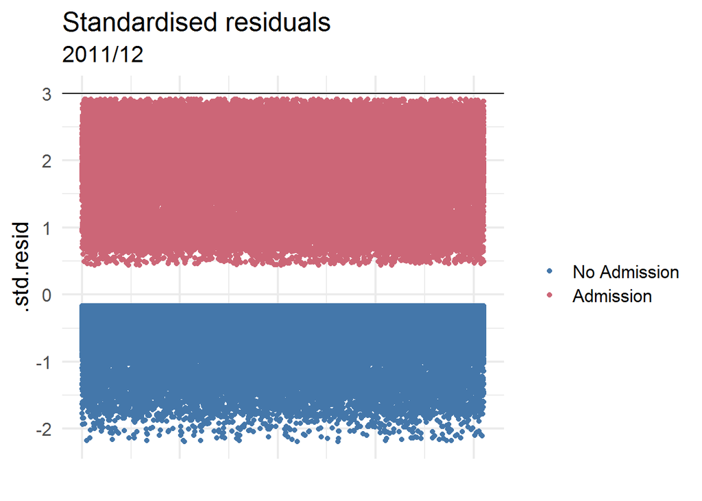

```r
adm_model_1 %>%
  filter(year == ymd(20120331)) %>%
  unnest(.$aug_var) %>%
  mutate(index = 1:n())-> aug_data_1112

aug_data_1112 %>%
  ggplot(aes(index, .std.resid, colour = adm_six)) +
  geom_point() +
  geom_hline(yintercept = 3) +
  scale_colour_ptol() +
  theme(axis.text.x = element_blank()) + #supress index for SDC
  labs(title = "Standardised residuals",
       subtitle = "2011/12",
       colour = "",
       x = "")
```

Once more, poor $R^2$ values but residuals look better than social care models! Whatever..

## Marginal effects

Now to look at AMEs

```r
adm_model_1 %>%
  unnest(marginals) %>%
  round_df(dig = 3) %>%
  arrange(year, AME) %>%
  mutate(order = row_number())-> usc_marginal


#Tidy up labels
prefixes <- c("sex")
usc_marginal$factor <- prefix_strip(usc_marginal$factor, prefixes)
usc_marginal$factor <- prefix_replace(usc_marginal$factor, "Meds_grp",
                                       "Meds: ")
usc_marginal$factor <- prefix_replace(usc_marginal$factor,
                                       "Age_grp", "Age: ")
usc_marginal$factor <- prefix_replace(usc_marginal$factor,
                                       "Simd", "SIMD Decile: ",
                                       toTitle = FALSE)
usc_marginal$factor <- prefix_replace(usc_marginal$factor,
                                       "scs_flag", "")
usc_marginal$factor <- prefix_replace(usc_marginal$factor,
                                       "dod_six", "")
usc_marginal$factor <- prefix_replace(usc_marginal$factor,
                                       "usc_flag", "")
usc_marginal$factor <- prefix_replace(usc_marginal$factor,
                                       "care_home", "")
#usc_marginal
my_datatable(usc_marginal)
```

|  | year | factor | AME | SE | z | p | lower | upper | order |
| --- | --- | --- | --- | --- | --- | --- | --- | --- | --- |
| 1 | 2012-03-31 | Female | -0.015 | 0.001 | -24.23 | 0 | -0.016 | -0.014 | 1 |
| 2 | 2012-03-31 | Care Home | -0.004 | 0.001 | -2.984 | 0.003 | -0.006 | -0.001 | 2 |
| 3 | 2012-03-31 | SIMD Decile: | -0.003 | 0 | -23.062 | 0 | -0.003 | -0.002 | 3 |
| 4 | 2012-03-31 | Age: 70-74 | 0.009 | 0.001 | 9.888 | 0 | 0.007 | 0.011 | 4 |
| 5 | 2012-03-31 | Meds: 3-5 | 0.016 | 0.001 | 18.79 | 0 | 0.014 | 0.017 | 5 |
| 6 | 2012-03-31 | Age: 75-79 | 0.019 | 0.001 | 19.815 | 0 | 0.017 | 0.021 | 6 |
| 7 | 2012-03-31 | Age: 80-84 | 0.036 | 0.001 | 32.408 | 0 | 0.033 | 0.038 | 7 |
| 8 | 2012-03-31 | Meds: 6-8 | 0.036 | 0.001 | 40.154 | 0 | 0.034 | 0.038 | 8 |
| 9 | 2012-03-31 | Age: 85-89 | 0.051 | 0.001 | 34.156 | 0 | 0.048 | 0.054 | 9 |
| 10 | 2012-03-31 | Age: 95 Plus | 0.056 | 0.005 | 10.95 | 0 | 0.046 | 0.066 | 10 |

[output cut: 65 more lines]

75 rows here again- not explicitly going to report these as I show them in the plot, but I do want a table with *actual* values that I can refer too. The values (particularly in higher age bands) get larger in 2014/14 and 2015/16. This is likely due to the fact there is more (better) data in the SCS which included telecare/alarms at any time in financial year rather than just in census week. I’ll need to discuss this so need the numbers.

## Plot marginal effects

Plot the table

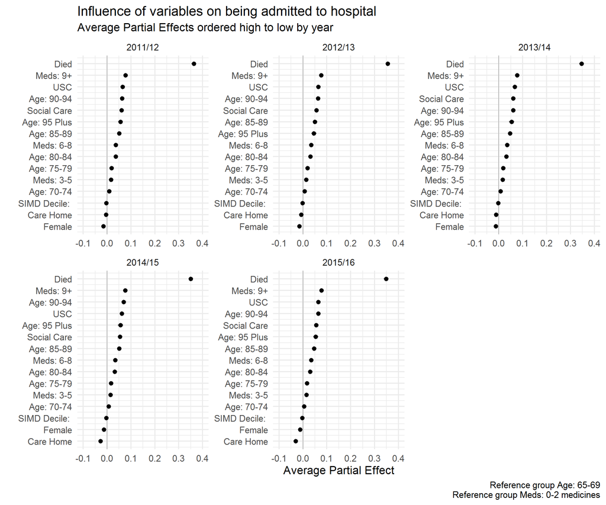

```r
usc_marginal %>%
  ggplot(aes(order, AME, ymin = lower, ymax = upper)) +
  geom_hline(yintercept = 0, colour = "#AAAAAA") +
  geom_pointrange() +
  facet_wrap(~year, labeller = as_labeller(year_labels), scales = "free") +
  scale_y_continuous(limits = c(-0.1, 0.4),
                     breaks = scales::pretty_breaks()) +
  scale_x_continuous(breaks = usc_marginal$order,
                     labels = usc_marginal$factor) +
  coord_flip() +
  labs(x = "",
       y= "Average Partial Effect",
       title = "Influence of variables on being admitted to hospital",
       subtitle = "Average Partial Effects ordered high to low by year",
       caption = "Reference group Age: 65-69\nReference group Meds: 0-2 medicines") -> adm_model_1_AME_plot

adm_model_1_AME_plot
```

## Plot SIMD

SIMD id different from the rest as it is modelled as a continuous variable. I’m going to produce a separate plot for it to make interpretation easier.

```r
adm_model_1 %<>%
  mutate(cplot_simd = map2(mod_var, year_data,
                           ~cplot(.x, data = .y, x = "simd", draw=FALSE)))
```

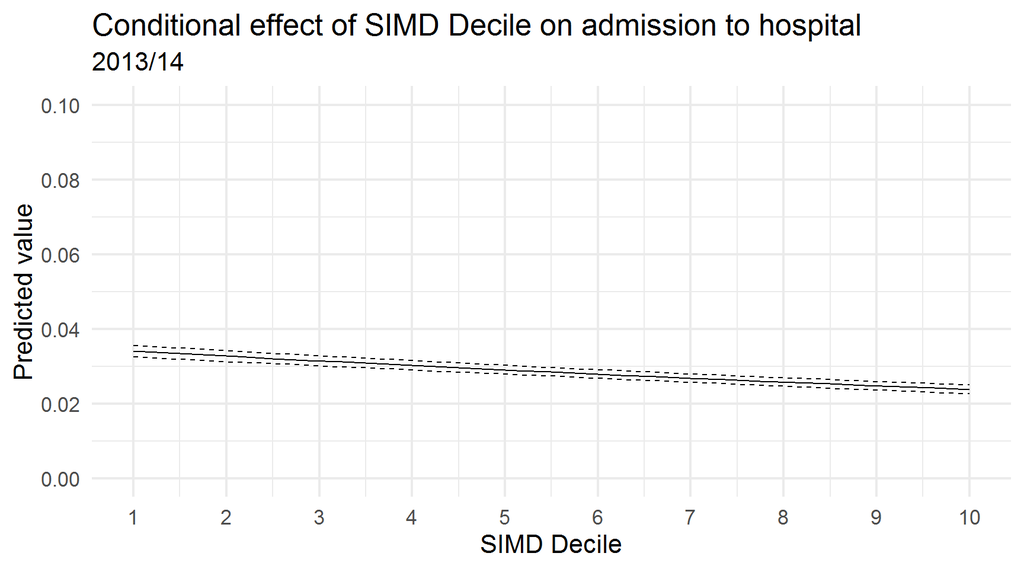

```r
adm_model_1 %>%
  filter(year == ymd(20140331)) %>%
  unnest(cplot_simd) %>%
  ggplot(aes(x = xvals)) +
  geom_line(aes(y = yvals)) +
  geom_line(aes(y = upper), linetype = 2) +
  geom_line(aes(y = lower), linetype = 2) +
  scale_x_continuous(breaks = scales::pretty_breaks(n = 10)) +
  scale_y_continuous(breaks = scales::pretty_breaks(),
                     limits = c(0, 0.1)) +
  labs(title = "Conditional effect of SIMD Decile on admission to hospital",
       subtitle = "2013/14",
       x = "SIMD Decile",
       y = "Predicted value") -> adm_model_1_simd_plot
adm_model_1_simd_plot
```

```r
ggsave("Research/created_objects/plots/final_plots/usc_models/adm_model_1_simd_plot.png",
       adm_model_1_simd_plot, width = 9, dpi = 600)
```

## Plot difference over time

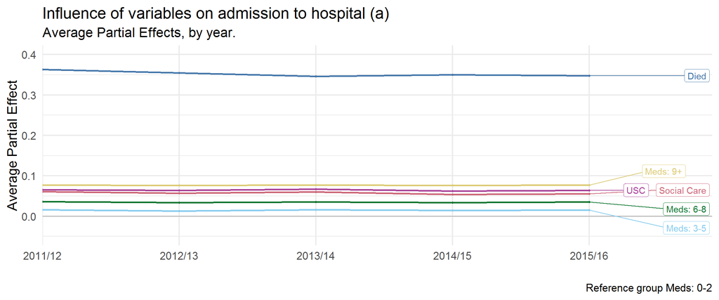

```r
usc_marginal %<>%
  mutate(year = case_when(!!!year_char))

usc_marginal %>%
  filter(factor %in% c("Died", "Meds: 3-5", "Meds: 6-8", "Meds: 9+",
                       "Social Care", "USC")) %>%
  mutate(label = if_else(year == max(year),
                         as.character(factor), NA_character_)) %>%
  ggplot(aes(year, AME,
             group = factor,
             colour = factor,
             ymin = lower,
             ymax = upper)) +
  geom_point(size = 0.9) +
  geom_path(size = 0.9) +
  geom_hline(yintercept = 0, colour = "#AAAAAA") +
  geom_label_repel(aes(label = label), nudge_x = 2) +
  scale_color_ptol(guide = "none") +
  scale_y_continuous(limits = c(-0.05, 0.4),
                     breaks = scales::pretty_breaks()) +
  scale_x_discrete(expand = expand_scale(add = c(0, 0.9))) +
  theme(legend.position = "top") +
  labs(x = "",
       y= "Average Partial Effect",
       colour = "",
       title = "Influence of variables on admission to hospital (a)",
       subtitle = "Average Partial Effects, by year.",
       caption = "Reference group Meds: 0-2") -> adm_model_1_AME_time_a
adm_model_1_AME_time_a
```

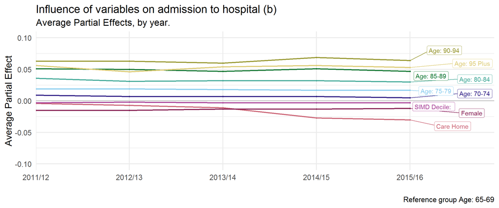

```r
usc_marginal %>%
  filter(factor %nin% c("Died", "Meds: 3-5", "Meds: 6-8", "Meds: 9+",
                       "Social Care", "USC")) %>%
  mutate(label = if_else(year == max(year),
                         as.character(factor), NA_character_)) %>%
  ggplot(aes(year, AME,
             group = factor,
             colour = factor,
             ymin = lower,
             ymax = upper)) +
  geom_point(size = 0.9) +
  geom_path(size = 0.9) +
  geom_hline(yintercept = 0, colour = "#AAAAAA") +
  geom_label_repel(aes(label = label), nudge_x = 0.5) +
  scale_color_ptol(guide = "none") +
  scale_y_continuous(limits = c(-0.1, 0.1),
                     breaks = scales::pretty_breaks()) +
  scale_x_discrete(expand = expand_scale(add = c(0, 0.9))) +
  labs(x = "",
       y= "Average Partial Effect",
       colour = "",
       title = "Influence of variables on admission to hospital (b)",
       subtitle = "Average Partial Effects, by year.",
       caption = "Reference group Age: 65-69") -> adm_model_1_AME_time_b
adm_model_1_AME_time_b
```